# R Notebook

```r
library(tidyverse)
library(palmerpenguins)

penguins_df <- penguins
penguins_df
```

| species | island | bill_length_mm | bill_depth_mm | flipper_length_mm | body_mass_g | sex | year |
| --- | --- | --- | --- | --- | --- | --- | --- |
| Adelie | Torgersen | 39.1 | 18.7 | 181 | 3750 | male | 2007 |
| Adelie | Torgersen | 39.5 | 17.4 | 186 | 3800 | female | 2007 |
| Adelie | Torgersen | 40.3 | 18.0 | 195 | 3250 | female | 2007 |
| Adelie | Torgersen | NA | NA | NA | NA | NA | 2007 |
| Adelie | Torgersen | 36.7 | 19.3 | 193 | 3450 | female | 2007 |
| Adelie | Torgersen | 39.3 | 20.6 | 190 | 3650 | male | 2007 |
| Adelie | Torgersen | 38.9 | 17.8 | 181 | 3625 | female | 2007 |
| Adelie | Torgersen | 39.2 | 19.6 | 195 | 4675 | male | 2007 |
| Adelie | Torgersen | 34.1 | 18.1 | 193 | 3475 | NA | 2007 |
| Adelie | Torgersen | 42.0 | 20.2 | 190 | 4250 | NA | 2007 |

[output cut: 334 more lines]

# Running a Chi Squared Test for Independence

```r
chisq.test(x = penguins_df$species, y = penguins_df$sex)
```

```
    Pearson's Chi-squared test

data:  penguins_df$species and penguins_df$sex
X-squared = 0.048607, df = 2, p-value = 0.976
```

H_null: Penguin species and sex are independent H_alternative: Penguins species and sex are NOT independent

Conclusion: We fail to reject the null hypothesis and conclude that penguins species and sex are independent

# One Way ANOVA

H_null: Means of all the groups are not different H_alternative: The mean of at least one of the groups is different

## Descriptive Stats

Interested in the flipper size of penguins

```r
penguins_df %>%
  group_by(species) %>%
  summarize(
    mean_flipper_length = mean(flipper_length_mm, na.rm = TRUE)
  )
```

| species | mean_flipper_length |
| --- | --- |
| Adelie | 189.9536 |
| Chinstrap | 195.8235 |
| Gentoo | 217.1870 |

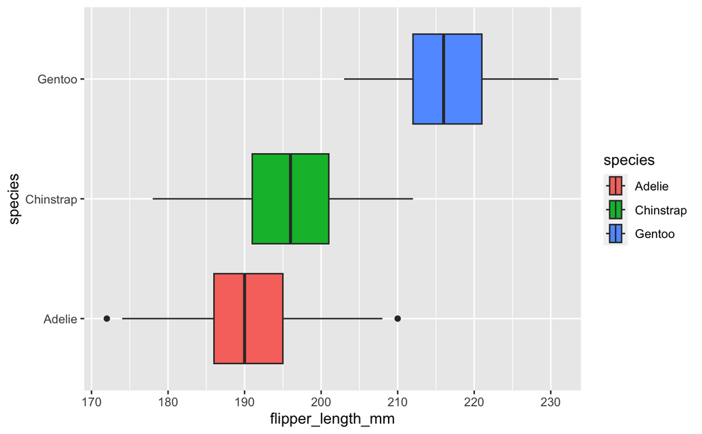

```r
penguins_df %>%
  ggplot() +
    geom_boxplot(aes(y = species, x = flipper_length_mm, fill = species))
```

```r
model <- aov(flipper_length_mm ~ species, data = penguins_df)
summary(model)
```

```
             Df Sum Sq Mean Sq F value Pr(>F)
species       2  52473   26237   594.8 <2e-16 ***
Residuals   339  14953      44
---
Signif. codes:  0 ‘***’ 0.001 ‘**’ 0.01 ‘*’ 0.05 ‘.’ 0.1 ‘ ’ 1
2 observations deleted due to missingness
```

H_null: Means of flipper lengths of all penguin species are not different H_alternative: The mean flipper length of at least one penguin species is different

Conclusions: We reject the null hypothesis and conclude that the mean flipper length of at least one penguin species is different

# Post Hoc Analysis

```r
gentoo_flippers <- penguins_df %>%
  filter(species == "Gentoo", sex == "male") %>%
  pull(flipper_length_mm)
adelie_flippers <- penguins_df %>%
  filter(species == "Adelie", sex == "male") %>%
  pull(flipper_length_mm)
chinstrap_flippers <- penguins_df %>%
  filter(species == "Chinstrap", sex == "male") %>%
  pull(flipper_length_mm)
```

```r
gentoo_flippers
```

## Gentoo vs Adelie

```r
t.test(x = gentoo_flippers, y = adelie_flippers)
```

[output not shown]

## Adelie vs Chinstrap

```r
t.test(x = chinstrap_flippers, y = adelie_flippers)
```

[output not shown]

## Chinstrap vs Gentoo

```r
t.test(x = chinstrap_flippers, y = gentoo_flippers)
```

[output not shown]

At a significance level of 0.05, the probability of a type I error for one is 0.05 For two tests, it would be 1 - (1 - 0.05)^2 For 3 tests, it would be 1 - (1- 0.05)^3

```r
 1 - (1 - 0.05)^2
```

```r
 1 - (1 - 0.05)^3
```

Bonferroni Correction: Since we are doing 3 tests, we divide our significance level by 3 Instead of comparing p_value. to significance level for each test, compare p_value to significance_level/3 for each test

```r
0.05/3
```

# Two way ANOVA

```r
model <- aov(flipper_length_mm ~ species * sex, data = penguins_df)
summary(model)
```

[output not shown]